# Data Challenge #2

Review the data:

```r
rm(list = ls(all = TRUE))   # cleans everything in the workspace

library(readr)          # easier reading of flat files
library(caret)          # classification and regresssion training package
library(randomForest)   # Random Forests package
```

```r
# ::::::: SOME USEFUL DEFINITIONS :::::::::::::::::::::::::::::::::::::::::::::

# set the general path for the project at its root, specific files will define
# their own branches individually
# NOTE that specifying your path will be different in Windows

path <- "/Users/StephanieLangeland/Desktop/Columbia/Applied Data Science/Git/QMSS_G5069_Applied_D_S/Data Challenges/datachallenge2" ## Stephanie's path

# path <- "C:\\Users\\Brandon\\Documents\\GitHub\\QMSS_G5069_Applied_D_S\\Data Challenges\\datachallenge2" ## Brandon's path

# path <- "" ## Zach's path

# define additional paths for files you will use. In each case, determine
# appropriate additions to the path

inFileName1   <- "data/processed/AllViolenceData_170216.csv"     # cleaned data on violence
outFileName1  <- "graphs/RF_VarImportance.pdf"
outFileName2  <- "graphs/RF_MSE.pdf"

# ::::::: APPLY INITIAL DEFINITIONS :::::::::::::::::::::::::::::::::::::::::::

# set your path to that defined above, and confirm it
setwd(path)
getwd()
```

```
## [1] "/Users/StephanieLangeland/Desktop/Columbia/Applied Data Science/Git/QMSS_G5069_Applied_D_S/Data Challenges/datachallenge2"
```

```r
# :::::::::::::::::::::::::::::::::::::::::::::::::::::::::::::::::::::::::::::
# :::::::::::::::::::::: LOADS DATA :::::::::::::::::::::::::::::::::::::::::::


# ::::::: LOADING RAW DATA
# note that read_csv() guesses column types, so that date is read as a date
# very useful for plotting time series

AllData <- read_csv(inFileName1)
# rough validations that data was correctly loaded
## names(AllData)
## nrow(AllData)
## summary(AllData)

## The authories involved in each event are noted in their own columns in the
## dataset.  For example when `AllData$army == 1` the army was involved.
## Guide to authority lookup:
auth_lookup <- "data/external/LookupAuthorityNames.csv"
auth_lookup_data <- read.csv(auth_lookup)
```

This is a team assignment. Please create a file on your team GitHub repo where you answer the challenge, including links to your code, and graphs.

# **Model #1 for question #1:**

### 1.) Ask two (2) questions that might help you understand better the dynamics of

### violence contained on our dataset. Apply one algorithm per question and share

### your insights from each analysis. [50 pts] Remember: a non-finding is also a

### finding! It tells you whether a question is worth pursuing further or not.

- Which regression model best predicts whether or not people will be detained using all weapons (defined as `clips.seized`, `cartridge.sezied`, `small.arms.seized`, `long.guns.seized`) seized and wounded organized crime members as predictors?

### 1a) perform the necessary transformations in your data - if any are needed,

### and explain why you did that

- The variables `clips.seized`, `cartridge.sezied`, `small.arms.seized`, `long.guns.seized` will be summed into one variable named `weapons_seized`.
- A new variable will be created named `detained_resp` to record whether people where detained (`1`) or not (`0`) in order to predict the response of whether people will be detained or not.

```r
AllData$weapons_seized <- transform(AllData$clips.seized +
                                      AllData$cartridge.sezied +
                                      AllData$small.arms.seized +
                                      AllData$long.guns.seized)

typeof(AllData$weapons_seized)
```

```
## [1] "list"
```

```r
AllData$weapons_seized <- as.numeric(unlist((AllData$weapons_seized))) # convert
# from list to numeric for regression models

AllData$detained_resp <- ifelse(AllData$detained > 0, 1, 0)

AllData <- as.data.frame(AllData)
```

### 1b) show the output from your analysis in a consumable form

- **Regression Models:**

```r
set.seed(1234)  # for reproducibility
train <- sample(nrow(AllData), 2698) # randomly sample half of the data
training <- AllData[train, ] # create training set
testing <- AllData[-train, ] # create testing set

linear <- lm(detained_resp ~ weapons_seized + organized.crime.wounded,
             data = training) # linear regression

quadratic <- lm(detained_resp ~ poly(weapons_seized + organized.crime.wounded, degree = 2),
                data = training) # quadratic regression

cubic <- lm(detained_resp ~ poly(weapons_seized + organized.crime.wounded, degree = 3),
            data = training) # cubic regression

quartic <- lm(detained_resp ~ poly(weapons_seized + organized.crime.wounded, degree = 4),
              data = training) # quartic regression

p_linear <- predict(linear, newdata = testing, type = "response") # predict the repsonse
p_liner_table <- confusionMatrix(testing$detained_resp,
                                 as.integer(p_linear > 0.5)) # confusion matrix

p_quadratic <- predict(quadratic, newdata = testing, type = "response")
p_quadratic_table <- confusionMatrix(testing$detained_resp, as.integer(p_quadratic > 0.5))

p_cubic <- predict(cubic, newdata = testing, type = "response")
p_cubic_table <- confusionMatrix(testing$detained_resp, as.integer(p_cubic > 0.5))

p_quartic <- predict(quartic, newdata = testing, type = "response")
p_quartic_table <- confusionMatrix(testing$detained_resp, as.integer(p_quartic > 0.5))
```

- **Regression Results:** A confusion matrix was constructed for each of the models and ranked in order from worst to best prediction accuracy:

```r
p_quadratic_table # quadratic regression confusion matrix
```

```
## Confusion Matrix and Statistics
##
##           Reference
## Prediction    0    1
##          0 1889   22
##          1  760   27
##
##                Accuracy : 0.7102
##                  95% CI : (0.6926, 0.7272)
##     No Information Rate : 0.9818
##     P-Value [Acc > NIR] : 1
##
##                   Kappa : 0.0315
##  Mcnemar's Test P-Value : <2e-16
##
##             Sensitivity : 0.71310
##             Specificity : 0.55102
##          Pos Pred Value : 0.98849
##          Neg Pred Value : 0.03431
##              Prevalence : 0.98184
##          Detection Rate : 0.70015
##    Detection Prevalence : 0.70830
##       Balanced Accuracy : 0.63206
##
##        'Positive' Class : 0
##
```

```r
p_liner_table # linear regression confusion matrix
```

```
## Confusion Matrix and Statistics
##
##           Reference
## Prediction    0    1
##          0 1880   31
##          1  748   39
##
##                Accuracy : 0.7113
##                  95% CI : (0.6938, 0.7283)
##     No Information Rate : 0.9741
##     P-Value [Acc > NIR] : 1
##
##                   Kappa : 0.0455
##  Mcnemar's Test P-Value : <2e-16
##
##             Sensitivity : 0.71537
##             Specificity : 0.55714
##          Pos Pred Value : 0.98378
##          Neg Pred Value : 0.04956
##              Prevalence : 0.97405
##          Detection Rate : 0.69681
##    Detection Prevalence : 0.70830
##       Balanced Accuracy : 0.63626
##
##        'Positive' Class : 0
##
```

```r
p_quartic_table # quartic regression confusion matrix
```

```
## Confusion Matrix and Statistics
##
##           Reference
## Prediction    0    1
##          0 1850   61
##          1  713   74
##
##                Accuracy : 0.7131
##                  95% CI : (0.6956, 0.7301)
##     No Information Rate : 0.95
##     P-Value [Acc > NIR] : 1
##
##                   Kappa : 0.0821
##  Mcnemar's Test P-Value : <2e-16
##
##             Sensitivity : 0.72181
##             Specificity : 0.54815
##          Pos Pred Value : 0.96808
##          Neg Pred Value : 0.09403
##              Prevalence : 0.94996
##          Detection Rate : 0.68569
##    Detection Prevalence : 0.70830
##       Balanced Accuracy : 0.63498
##
##        'Positive' Class : 0
##
```

```r
p_cubic_table # cubic regression confusion matrix
```

```
## Confusion Matrix and Statistics
##
##           Reference
## Prediction    0    1
##          0 1875   36
##          1  737   50
##
##                Accuracy : 0.7135
##                  95% CI : (0.696, 0.7305)
##     No Information Rate : 0.9681
##     P-Value [Acc > NIR] : 1
##
##                   Kappa : 0.0606
##  Mcnemar's Test P-Value : <2e-16
##
##             Sensitivity : 0.71784
##             Specificity : 0.58140
##          Pos Pred Value : 0.98116
##          Neg Pred Value : 0.06353
##              Prevalence : 0.96812
##          Detection Rate : 0.69496
##    Detection Prevalence : 0.70830
##       Balanced Accuracy : 0.64962
##
##        'Positive' Class : 0
##
```

***Analysis of the output:** The cubic regression model had the highest prediction accuracy of 0.7135 or 71.35% in using wounded organized crime members and all weapons seized to predict whether people would be detained or not. The cubic confusion matrix shows that the model correctly predicted that no one would be detained 1,875 times and people would be detained 50 times. Although the model has the highest prediction accuracy, it is mainly driven by correct predictions of no one being detained. Overall, it does not successfully predict when people will be detained. Therefore, this model will not help Mexican authorities understand drivers of detention rates, since it does not consistently predict how the number of organized crime members wounded and weapons seized relate to whether people are detained or not. Furhermore, the model incorrectly predicted that people would be detained in 737 events when no one was detained. It also incorrectly predicted that people would not be detained when people were detained in 36 events.

### 1c) be explicit about the limitations of your anaylisis, due to estimation

### or to the data itself

- The limitations of the cubic regression model are shown through various diagnostic plots using the entire dataset. Refer to the analysis below the plots.

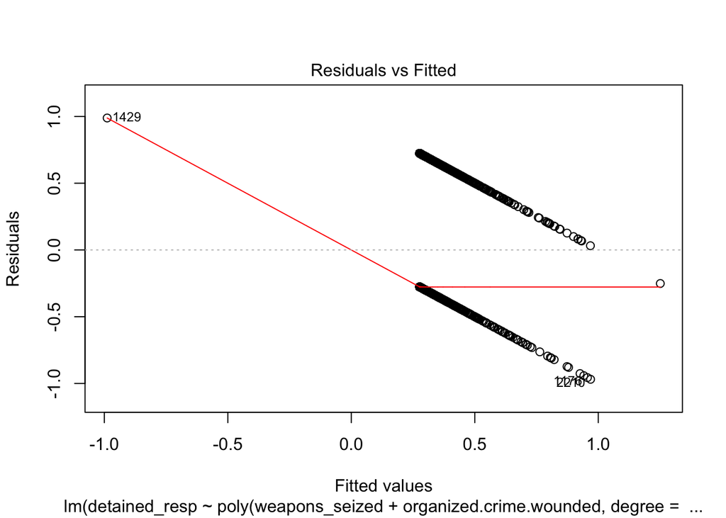

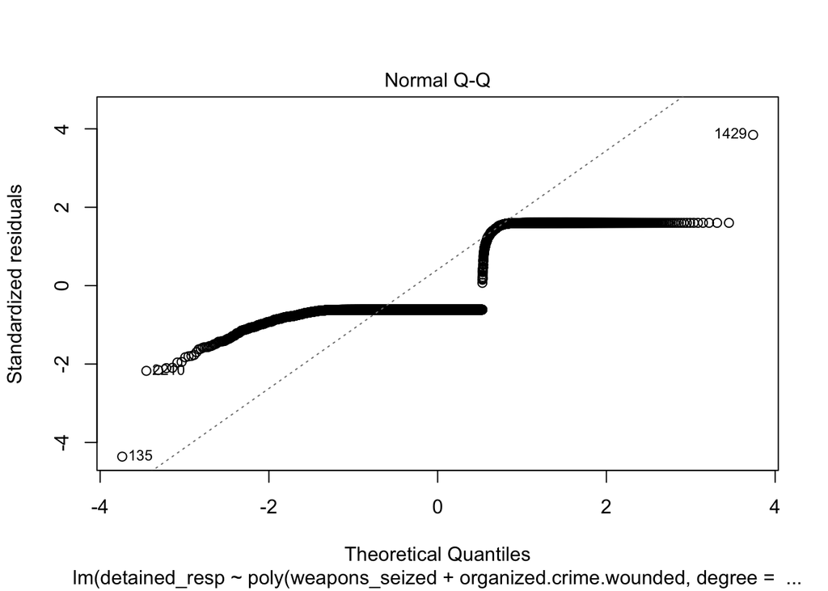

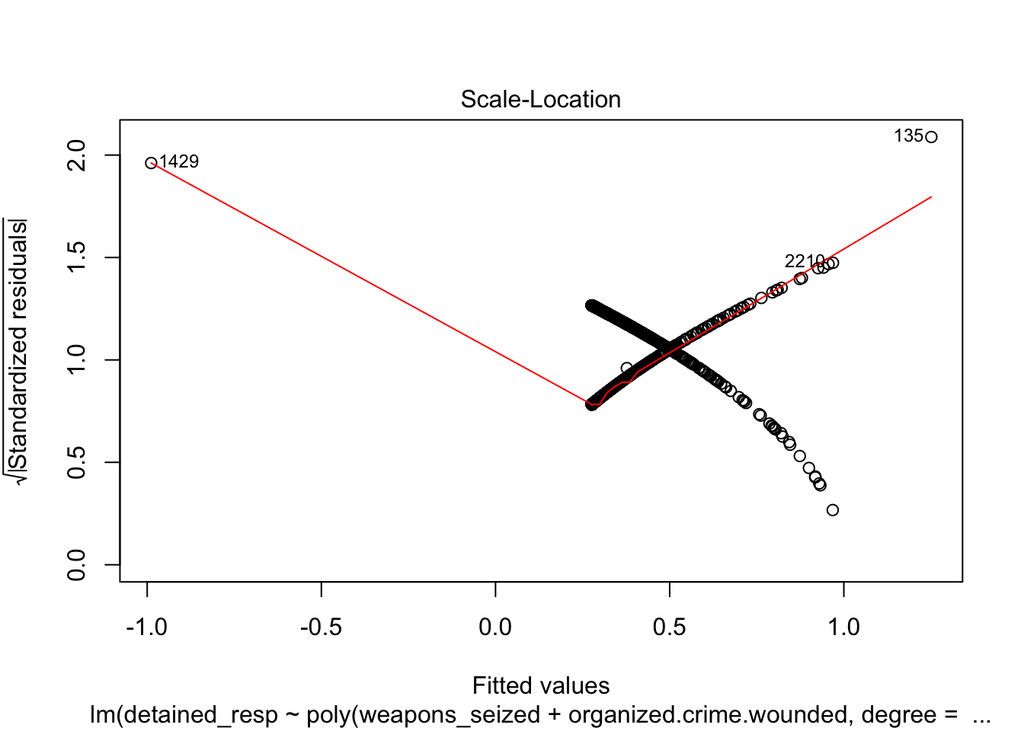

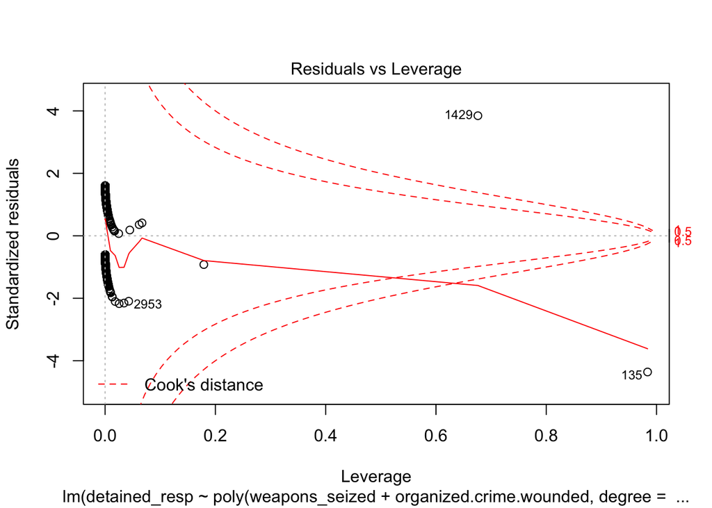

```r
plot(lm(detained_resp ~ poly(weapons_seized + organized.crime.wounded, degree = 3),
        data = AllData)) # cubic regression
```

1.) **Residuals vs Fitted plot:** This plot shows whether the residuals have non-linear patterns. Although the cubic model had the highest prediction accuracy of all the regression models,the residuals do not show cubic relationship on this plot, but rather two linear lines that have a clear turning point. Therefore, the cubic nature of the model may not actually be the most appropriate fit for the data. This may help explain why there was unbalanced prediction accuracy in that more “not detained” cases were predicted than “detained” cases.

2.) **Normal Q-Q plot:** This plot shows whether the residuals are normally distributed.  
Since the residuals on the graph do not follow the straight dashed line, the data are not normally distributed. This may represent bias or skewness in the data, which may be attributed to unbalanced cases of detained versus not detained. If this is the case, this may support the claim that there are more cases of people not being detained.

3.) **Scale-Location plot:** This plot shows whether the residuals are spread equally along the ranges of predictors. Since the predictors are not equally spread throughout the graph, this suggests that the data suffer from heterscedasticity, meaning that variance among the residuals is not equal. This seriously undermines the validity of the model because the modeling errors my not be uncorrelated and uniform.

4.) **Residuals vs Leverage plot:** This plot illumiates outliers that may be influential to regresson results. The extreme outliers # 135 and 1429 are outside of the Cook’s distance (represented by the dotted line). These cases are influential to the regression results, which will be altered if these cases are excluded from the model.

**Conclusion:** Given the analysis of the diagnostic plots above, the cubic model has serious limitations that violate the basic regression assumptions. These limitations may invalidate the regression results. The severity of these limitations may become less influential as more data are collected. As more data are collected, theoretically, the distribution should normalize and become homoscedastic.

### 1d) did you find something interesting? what is that? does your finding

### suggest this question is worth pursuing further? why or why not?

```
* It is interesting that the cubic model predicts the best out of all the models
but the predicitons are skewed towards predicting when no one will be detained.
This skewness in the prediction may be attributed to the findings noted in #1c
above related to the violations of regression assumptions, especially that the
data are notmally distributed. Predicting whether or not people will be detained
using all weapons seized and wounded organized crime members as predictors is not
worth pursuing because the model poorly predicts cases when people will be detained.
Moreover, since the model is not in compliance with the regression assumptions, the
results may not be true findings.
```

### 1e) if you did not find something interesting, explain why, and whether

### there is some additional information that would help in answering your question

- The poor prediction accuracy of the cubic model in predicting when people will be detained may be attributed to the skewness of the data. Below, we see that there were 3,787 events when no one was detained and 1,609 when people were detained. Therefore, the model may not have enough data to better predict when people will be detained. The model may be more effective once more data are collected and the data become normally distributed.

```r
nrow(AllData[AllData$detained_resp == "0",]) # Number of events when no one was detained
```

```
## [1] 3787
```

```r
nrow(AllData[AllData$detained_resp == "1",]) # Number of events when people were detained
```

```
## [1] 1609
```

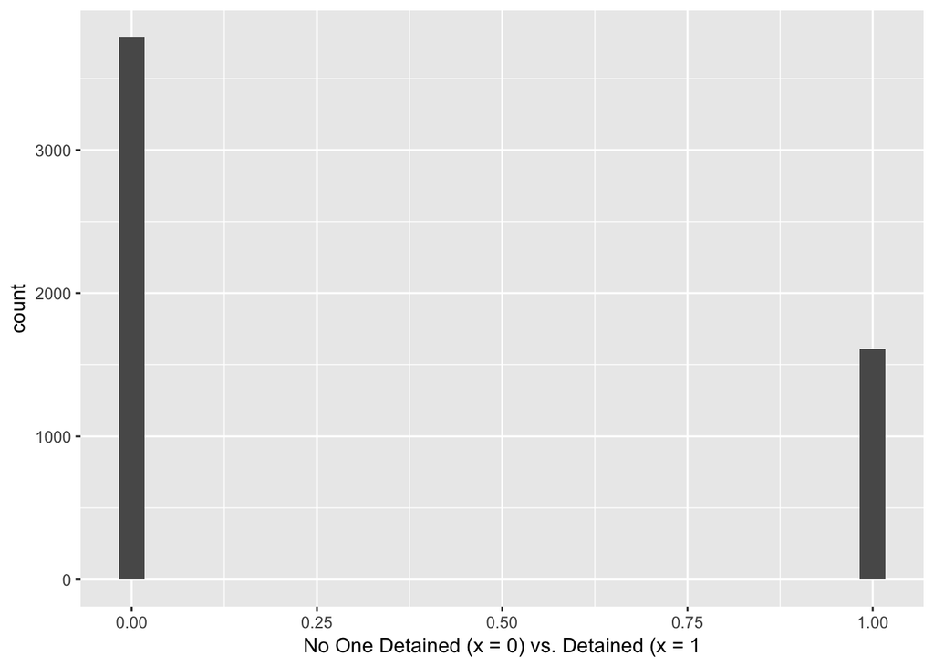

```r
library(ggplot2)

ggplot(data = AllData) +
  geom_histogram(mapping = aes(detained_resp)) +
  xlab("No One Detained (x = 0) vs. Detained (x = 1")
```

### 1f) provide your code, and a single visualization per question that summarizes

### your finding

- To contextualize the usefulness of the prediction model, the following visualizations show the total number of weapons seized when people are detained versus not detained and the total number of organized crime members wounded when people are detained versus not detained. These graphs should help the Mexican government decide whether it is worth pursuing a strategy centered around detaining more people if the goal is to maximize the number of weapons seized and organized crime members wounded.

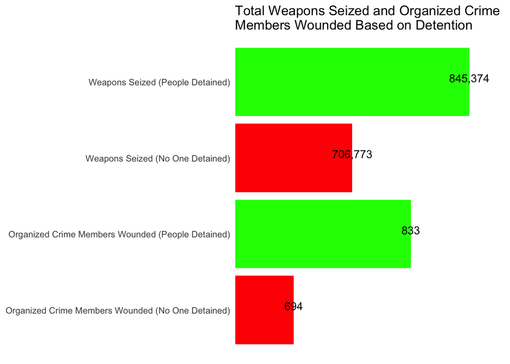

```r
detained_subset <- subset(AllData,
                          detained_resp == 1,
                          select = c(weapons_seized, organized.crime.wounded))

not_detained_subset <- subset(AllData,
                              detained_resp == 0,
                              select = c(weapons_seized, organized.crime.wounded))

det_weap_total <- sum(detained_subset$weapons_seized) # total weapons seized
# when people were detained

n_det_weap_total <- sum(not_detained_subset$weapons_seized) # total weapons seized
# when people were NOT detained

det_ocw_total <- sum(detained_subset$organized.crime.wounded) # total number of
# organized crime members wounded when people were detained

n_det_ocw_total <- sum(not_detained_subset$organized.crime.wounded) # total number of
# organized crime members wounded when people were NOT detained

total_figures <- data.frame(det_weap_total,
                            n_det_weap_total,
                            det_ocw_total,
                            n_det_ocw_total) # convert to data.frame

library(plyr)
# rename column headings:
total_figures <- rename(total_figures,
                        c("det_weap_total" = "Weapons Seized (People Detained)",
                          "n_det_weap_total" = "Weapons Seized (No One Detained)",
                          "det_ocw_total" =
                            "Organized Crime Members Wounded (People Detained)",
                          "n_det_ocw_total" =
                            "Organized Crime Members Wounded (No One Detained)"))

# Have numbers appear with commas:
total_figures$`Weapons Seized (People Detained)` <- prettyNum(
  total_figures$`Weapons Seized (People Detained)`,
  big.mark = ",",
  scientific = FALSE)

total_figures$`Weapons Seized (No One Detained)` <- prettyNum(
  total_figures$`Weapons Seized (No One Detained)`,
  big.mark = ",",
  scientific = FALSE)

total_figures$`Organized Crime Members Wounded (People Detained)` <- prettyNum(
  total_figures$`Organized Crime Members Wounded (People Detained)`,
  big.mark = ",",
  scientific = FALSE)

total_figures$`Organized Crime Members Wounded (No One Detained)` <- prettyNum(
  total_figures$`Organized Crime Members Wounded (No One Detained)`,
  big.mark = ",",
  scientific = FALSE)

total_figures_new <- t(total_figures) # transpose total_figures for graphing purposes
total_figures_new <- as.data.frame(total_figures_new) # convert to data.frame
total_figures_new$subject <- row.names(total_figures_new)
total_figures_new <- rename(total_figures_new,
                            c("V1" = "Totals"))

ggplot(data = total_figures_new, aes(y = Totals, x = subject, fill = subject)) +
  geom_bar(stat = "identity") +
  scale_fill_manual(values = c("red", "green", "red", "green")) +
  coord_flip() +
  ggtitle("Total Weapons Seized and Organized Crime\nMembers Wounded Based on Detention") + # title line break
  geom_text(aes(label = Totals), vjust = 0, colour = "black") +
  theme(axis.line = element_blank(),
        axis.text.x = element_blank(),
        axis.ticks = element_blank(),
        axis.title.x = element_blank(),
        axis.title.y = element_blank(),
        legend.position = "none",
        panel.background = element_blank(),
        panel.border = element_blank(),
        panel.grid.major = element_blank(),
        panel.grid.minor = element_blank(),
        plot.background = element_blank())
```

- The graph of all the data shows that when people are detained, more weapons are seized and organized crime members wounded. If the Mexican government’s goal is to maximize the number of weapons seized and organized crime members wounded, they should pursue a strategy that focuses on detaining people in each event. Although the cubic model does not predict when people will be detained based on thee varaibles as well as it predicts when people will not be detained, this issue may be solved once more data are collected. The current dataset is heavily skewed towards cases when no one was detained, as seen above in quest 1e. Once more data are colelcted, the distribution should normlaize and the cubc model may have a more balanced success rate.

### 1g) phrase your finding for each question in two ways:

### 1g-1) one sentence that summarizes your insight

- A cubic model used the number of organized crime members wounded and weapons seized per event to successfully predict when people will not be detained but not when people will be detained with the same level of accuracy.

### 1g-2) one paragraph that reflects all nuance in your insight

- A cubic model used the number of organized crime members wounded and weapons seized per event to successfully predict when people will not be detained but not when people will be detained with the same level of accuracy. The distribution of the data is not normal and skewed with more cases when people were not detained. Additionally, the data suffers from heteroscedasticity and extreme outliers that influence the regression results. Overall, the cubic model violates multiple regression assumptions and the ouput is not useful in predicting when people will be detained.

### 1h) make sure to also include your code

- The code is included under each quetsion above.

# **Model #2 for question #1:**

### 1. Ask two (2) questions that might help you understand better the dynamics of

### violence contained on our datas et. Apply one algorithm per question and share

### your insights from each analysis. [50 pts] Remember: a non-finding is also a

### finding! It tells you whether a question is worth pursuing further or not.

- Does the specific government group involved with an event (AFI, Army, Federal Police, Ministerial Police, Municipal Police, Navy, Other, and State Police) have a positive or negative relationship with Perfect Lethality? We can see from the graph below that there are about 1500 cases with perfect lethality therefore I believe it is acceptable to examine this question.

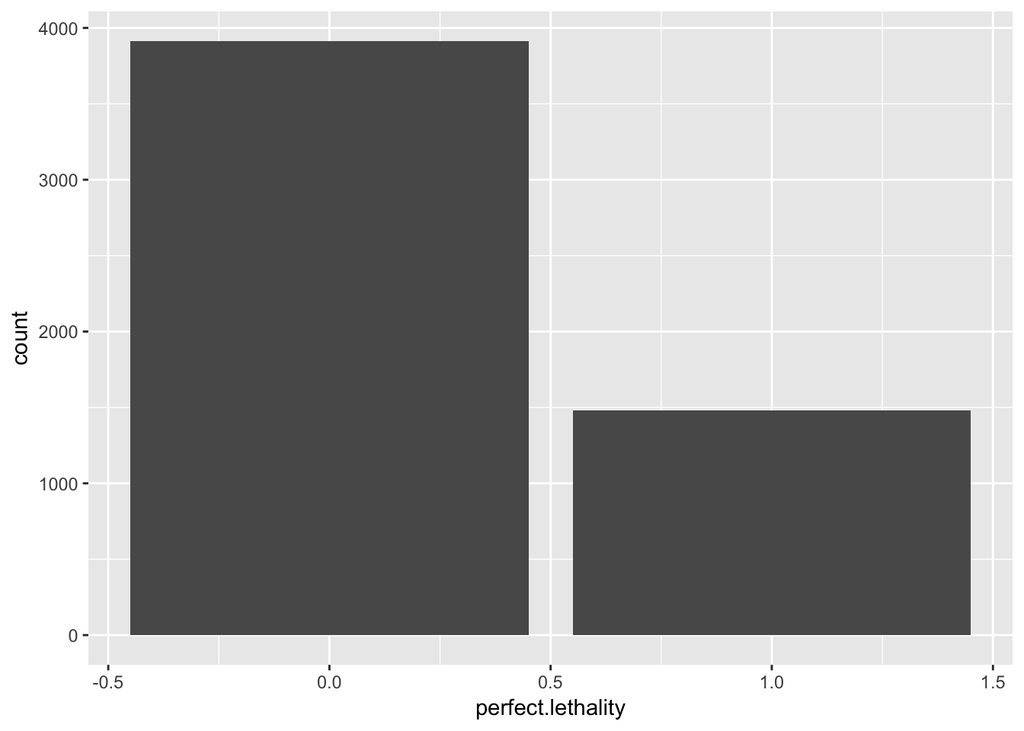

```r
library(ggplot2)
pl <- ggplot(AllData, aes(perfect.lethality))
pl + geom_bar()
```

### 1a perform the necessary transformations in your data - if any are needed,

### and explain why you did that

- We used the same code used above to create a variable for total weaponry seized (`weapons_seized`) by using the sum of the variables `clips.seized`, `cartridge.sezied`, `small.arms.seized`, `long.guns.seized`. This variable will be used in order to control for all weaponary seized in our analysis.

```r
# used Stephanie's code to create one variable to sum weaponry seized
AllData$weapons_seized <- transform(AllData$clips.seized +
                                      AllData$cartridge.sezied +
                                      AllData$small.arms.seized +
                                      AllData$long.guns.seized)
AllData$weapons_seized <- as.numeric(unlist((AllData$weapons_seized)))
```

### 1b show the output from your analysis in a consumable form

- In order to answer our hypothesis we ran a multiple logistic regression on perfect lethality by the involvment of the AFI, Army, Federal Police, Ministerial Police, Municipal Police, Navy, Other, and State Police. A number of control variables were also included which are municipality code, number of detained in the events, the date of each event, the total people dead in the events, the total people wounded in the events, weaponry seized in the events, and the source of the data for the events (Confrontations or Aggresions database). We are using logistic regression becuase the variables being used are binary (0,1).

```r
logit.perf_leth3 <- glm(perfect.lethality ~ afi + army + federal.police + ministerial.police + municipal.police + navy + other + state.police + mun_code + detained + date + total.people.dead + total.people.wounded + weapons_seized + source, family = binomial (link = logit), data = AllData)
summary(logit.perf_leth3)
```

```
##
## Call:
## glm(formula = perfect.lethality ~ afi + army + federal.police +
##     ministerial.police + municipal.police + navy + other + state.police +
##     mun_code + detained + date + total.people.dead + total.people.wounded +
##     weapons_seized + source, family = binomial(link = logit),
##     data = AllData)
##
## Deviance Residuals:
##     Min       1Q   Median       3Q      Max
## -8.4904  -0.6525  -0.2044   0.3100   4.3585
##
## Coefficients:
##                        Estimate Std. Error z value Pr(>|z|)
## (Intercept)          -9.104e+00  1.545e+00  -5.891 3.83e-09 ***
## afi                   6.573e-02  7.191e-01   0.091  0.92716
## army                  6.110e-01  9.737e-02   6.275 3.49e-10 ***
## federal.police        2.116e-01  1.378e-01   1.535  0.12472
## ministerial.police   -5.084e-02  1.782e-01  -0.285  0.77537
## municipal.police     -6.147e-02  1.356e-01  -0.453  0.65024
## navy                  5.555e-01  2.216e-01   2.507  0.01218 *
## other                -1.486e-02  2.585e-01  -0.057  0.95416
## state.police         -2.491e-02  1.698e-01  -0.147  0.88338
## mun_code              2.358e-03  9.525e-04   2.476  0.01329 *
## detained             -3.775e-02  1.691e-02  -2.232  0.02564 *
## date                  3.269e-04  1.029e-04   3.176  0.00149 **
## total.people.dead     8.258e-01  3.202e-02  25.793  < 2e-16 ***
## total.people.wounded -6.113e-01  3.782e-02 -16.162  < 2e-16 ***
## weapons_seized        1.018e-05  1.700e-05   0.599  0.54918
## sourceconfrontations  2.784e+00  1.852e-01  15.035  < 2e-16 ***
## ---
## Signif. codes:  0 '***' 0.001 '**' 0.01 '*' 0.05 '.' 0.1 ' ' 1
##
## (Dispersion parameter for binomial family taken to be 1)
##
##     Null deviance: 6341.9  on 5395  degrees of freedom
## Residual deviance: 4052.7  on 5380  degrees of freedom
## AIC: 4084.7
##
## Number of Fisher Scoring iterations: 7
```

### 1c be explicit about the limitations of your anaylisis, due to estimation